# EAEEE 4257: Homework 2

Sruti Devendran (sd3159)

2018-02-19

# HW2: Linear Regression and Trends

**DUE: Monday, 19 Feb, 2018 11:59 PM**

Over the past week or so we have been discussing trends and regression in class. At the same time, you’ve been learning some basic `R` programming on data camp. This homework will give you a chance to put these concepts together. You will get practice using `R` to visualize data, run regression models and trend tests, generate bootstrapts, and more.

While we have focused on statistical attributes in the lecture and in the learning objectives listed above, in the homework I would like to focus on the application of these ideas, with a view to posing questions that someone doing the analysis may ask and exploring how we could apply the techniques demonstrated to gain insights into these questions, and/or identify some of the difficulties involves in applying these ideas.

This homework is designed to be doable using only what we have learned in class, the assigned readings, and the `R` skills you have developed on data camp. However, the following references may be useful:

- Course notes, particularly lectures 4 and 5
- Helsel and Hirsch, Chapter 9 (linear models)
- Helsel and Hirsch, Chapter 12 (trend analysis)
- James et al “Introduction to Statistical Learning” (2013), Chatper 3 (linear regression)
- R for Data Science book

## Instructions

Please edit the `template.Rmd` file that has been provided to include your name and your UNI in the `author` block at the top of this page. You will find the codes provided in this document to be very helpful, particularly for reading in data and running the types of models we will need.

You will notice over the course of this semester that the assignments will gradually become more open-ended. Some questions have very specific “correct” answers, while others may be open to interpretation or may have many ways to answer. For open-ended questions, the most important thing is for you to describe:

- What is the model and what are the key variables we wish to look at?
- What are the assumptions of the model?
- How do I check whether the data support these assumptions and modify the model if necessary?
- What are the parameters of the model?
- How should these parameters be estimated?
- How do I assess the uncertainty in the estimation of the parameters from finite data?
- How do I map this estimate of uncertainty in model parameters into a probabilistic statement about the outcome of interest?
- What were the questions I was unable to answer given data or model limitations, and what may I need to address them?

It is relatively easy to run code using a computer thanks to tools like `R`, the `tidyverse`, etc. You will find that you spend more time than you would like de-bugging your code, trying to load data into `R`, and reading package documentation – that’s annoying but you will get better at it with time. The truly challenging – but also the most useful – part of statistical analysis is being able to connect your intuition (and scientific knowledge) about the world, data you have collected, and mathematical (statistical) models.

Please turn in your `.Rmd` file and the `.html` file which is output by running it. Questions that you are expected to answer or analysis that you are expected to carry out is indicated in bold **like this**

## Working in Teams

You are permitted to work in teams for this assignment, but (as the honor code you signed states) you must turn in your own work. Please list the name and UNI here of anyone you worked with at the end of this document.

# Getting Started

Here I will provide you with code to read in the data we will use. In future weeks you may be asked to download and read in data yourselves, which is more consistent with what you would do in a professional setting.

## Context

We’ve all heard about climate change; here we will analyze some climate data to form our own conclusions about global temperature. The data we will analyze comes mostly from http://www.johnstonsarchive.net/environment/co2table.html, but has been modified for the purposes of this class. For this homework, we won’t queestion the quality of this data, but you should be aware that there is actually substantial uncertainty in measurements of historical climate variables, such as the global average methane levels in 1881. In general, you should question the data you are analyzing!

We are going to think broadly about the following questions: - Is there a trend in global mean temperature? What is its statistical significance? - What drives global mean temperature?

You should note that to assert causality we do still need a quantifiable physical mechanism, so here we are merely talking about whether a predictor variable could statistically explain the trend. In large data sets it is easy to find spuriously correlated variables, or even non-spuriously correlated variables, that do not cause each other. For some hilarious examples, check out http://www.tylervigen.com/spurious-correlations. One definition of causality is based on precedence – e.g., a variable (e.g. rainfall) whose evolution leads (say by a few months) the evolution of the response variable (e.g., end of year crop yield) can be construed as causal, and a statistical test (based on Bayes theorem) can be used to generally assess the strength of such causality. However, in the absence of good physical arguments, even such arguments are not truly causal.

You should also note that the available predictor variables may be mutually correlated and may have feedback to the temperature series – e.g. an increase in temperature due to CO2 may in turn lead to increased atmospheric water vapor (donât have data) which increases temperature in the short run, and eventually leads to much higher biological production (intermediate variable – donât have data) which could reduce carbon dioxide and reduce temperature. Since we donât have data on intermediate variables, we canât really explore these causal chains, but it is important to keep them in mind as we look at the effects of these variables individually and together – we may want to use not just the concurrent value, but also prior values of these variables as predictors. Correlated predictors will allow us to only say something about the “joint” explanation of the trend by the predictors and we canât say something unequivocally about the % of the trend ascribed to a particular predictor.

## Loading Packages

We’ll start by getting the packages we need running. I like to use the `pacman` package manager which is the equivalent of calling `library()` or `require()` but also installs the package if it’s not already installed. If you don’t have it installed, you can run

```r
#install.packages('pacman')
```

And then we can call the packages we need like

```r
pacman::p_load(
  dplyr, # data manipulation
  readr, # reading in data
  ggplot2 # visualizing data
)
```

## Read in Data

We’re going to work with the global temperature data contained in `glob.csv`. It was included with HW1 on Courseworks – here I am assuming it is in the same folder as my `RMarkdown` document. Let’s read it in:

```r
temp <- readr::read_csv('glob.csv') %>%
  select(Year, Temp, CO2, CH4, sunspot, volcanic) %>%
  setNames(tolower(names(.))) # variable names are lower case
glimpse(temp)
```

```
Observations: 135
Variables: 6
$ year     <int> 1880, 1881, 1882, 1883, 1884, 1885, 1886, 1887, 1888,...
$ temp     <dbl> -0.225, -0.204, -0.212, -0.290, -0.403, -0.385, -0.36...
$ co2      <dbl> 290.7, 291.2, 291.7, 292.1, 292.6, 293.0, 293.3, 293....
$ ch4      <int> 908, 909, 910, 911, 913, 914, 915, 916, 918, 918, 919...
$ sunspot  <dbl> 32.241667, 54.308333, 59.608333, 63.633333, 63.508333...
$ volcanic <dbl> 0.0000, 0.0000, 0.0000, 0.0572, 0.0897, 0.0138, 0.033...
```

We can see that the data set provides information not only on temperature (`temp`) but also on time (`year`), on global $\text{CO}_2$ and $\text{CH}_4$ concentrations, on sunspot activity, and on volcanic eruptions.

## Exploratory Analysis

Which variables look to be most closely related? What physical mechanisms may explain this?

The following pairs of variables are closely related: Year and temperature are closely related. They appear to have a quadratic relationship Temperature and CH4 related. They also appear to have a quadratic relationship Temperature and Carbon DIoxide are linearly related: with clustering of points in the earlier period of the sampling.

The relation between the Year and temperature can be explained by global warming, which has started after the Industrial Revolution. It is from the the Industrial Revolution, that there is an increase in the concentration of greenhouse gases. This explains the relationhip between CO2 and Temp. Methane is also a strong greenhouse gas. It contributes to global warming, to a larger extent than an equivalent amount of carbon dioxide gas. This physical explanation supports the statistical relationship between the Temperature and CH4.

These variables are very closely related, and easily a curve can be fitted into the points. The deviation of the points from the curve will be very less. These variables are very closely related.

Year and CO2 have a quadratic relation- the relation seems to be very strong After the Industrial Revolution, the greenhouse gas conceentrations increased. Since the relation is drawn from the years after the industrial revolution, it appears to be consistent with this physical relationship Year and CH4 also related-very closely related-tight After the Industrial Revolution, the methane concentrations increased becasue of various avtivities. This further explains the strong statistical relationship between the two variable

C02 and CH4 are closely related-very tight: quadratic relationship This means that when carbon dioxide emissions increases, the methane concentration also increased.

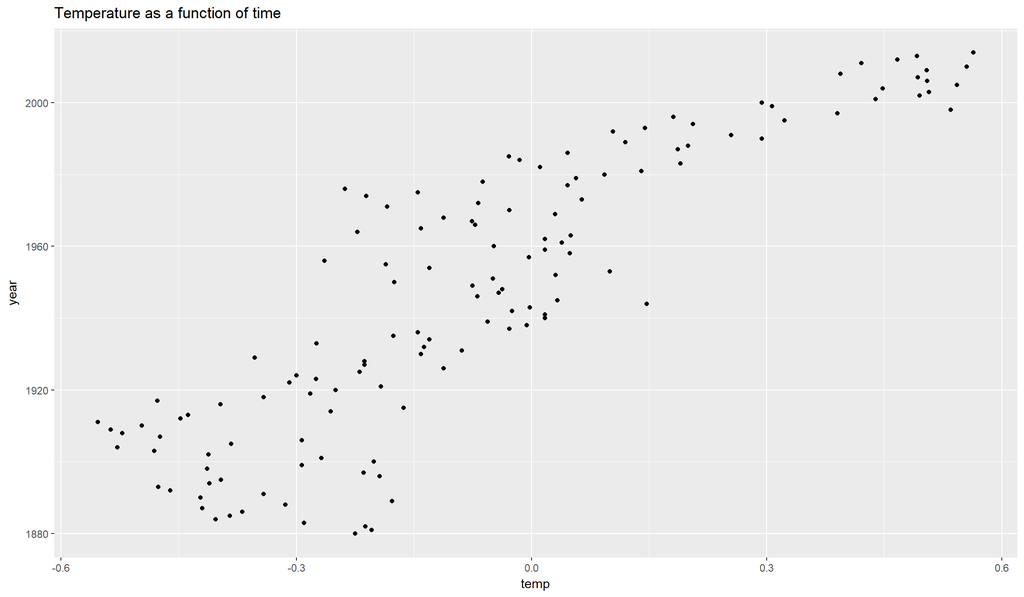

```r
ggplot(temp, aes(temp, year)) + geom_point() + ggtitle('Temperature as a function of time')
```

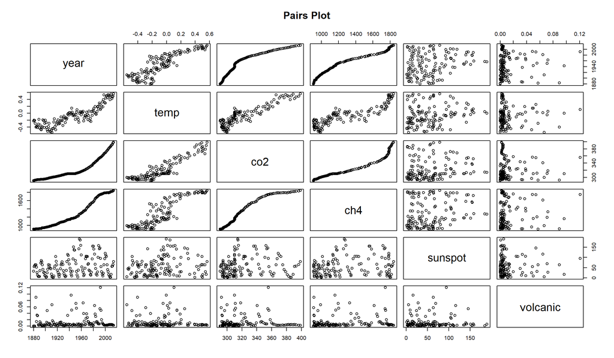

```r
pairs(temp, main="Pairs Plot")
```

# Analysis

In this section we will explore whether there is a time trend of global mean temperature.

## Is There a Trend?

There is a clear time trend of global mean temperature. There is an increase in the global mean temperature with time.

### Temperature Differences

We would like to know whether the temperatures towards the end of our data or the middle of our data is the same. The following code will create a variable `time_period` in the `temp` variable by dividing the `year` into 4 equal periods. I arbitrarily chose 4 bins for time; you should explore using different numbers of bins (see the `ntile` call below) to see if your results change.

```r
temp_period <-
  temp %>%
  mutate(time_period = ntile(year, 4))
glimpse(temp_period)
```

```
Observations: 135
Variables: 7
$ year        <int> 1880, 1881, 1882, 1883, 1884, 1885, 1886, 1887, 18...
$ temp        <dbl> -0.225, -0.204, -0.212, -0.290, -0.403, -0.385, -0...
$ co2         <dbl> 290.7, 291.2, 291.7, 292.1, 292.6, 293.0, 293.3, 2...
$ ch4         <int> 908, 909, 910, 911, 913, 914, 915, 916, 918, 918, ...
$ sunspot     <dbl> 32.241667, 54.308333, 59.608333, 63.633333, 63.508...
$ volcanic    <dbl> 0.0000, 0.0000, 0.0000, 0.0572, 0.0897, 0.0138, 0....
$ time_period <int> 1, 1, 1, 1, 1, 1, 1, 1, 1, 1, 1, 1, 1, 1, 1, 1, 1,...
```

```r
group <- temp_period %>%
          group_by(time_period)
summarize(group)
```

```
# A tibble: 4 x 1
  time_period
        <int>
1           1
2           2
3           3
4           4
```

Pick a measure of centrality and use `group_by` to group the data by the `temp_period` variable we created with the `summarize` command.

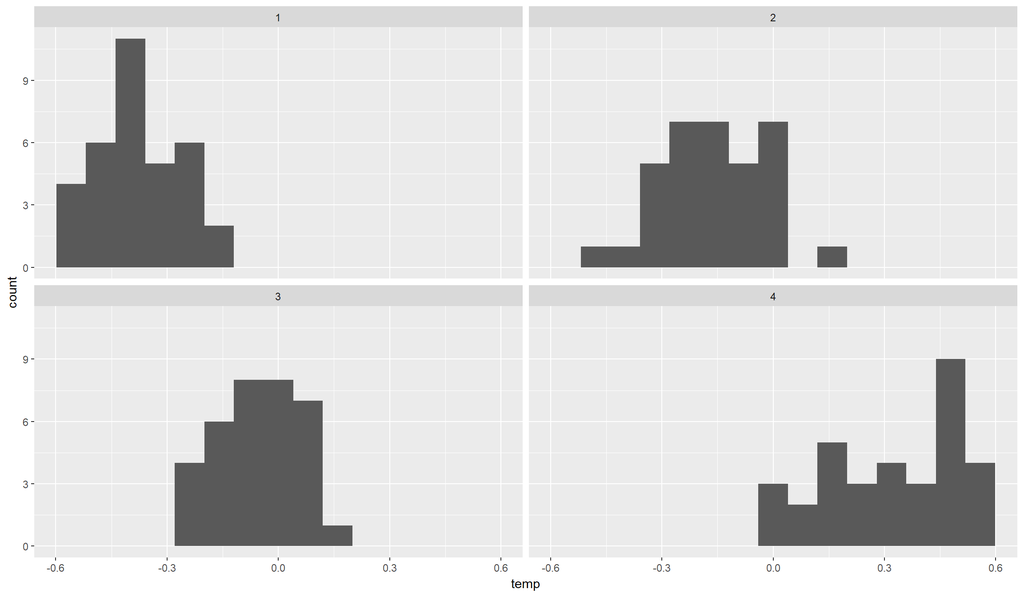

```r
ggplot(temp_period, aes(x=temp))+geom_histogram(bins=15)+facet_wrap('time_period')
```

Here we have characterized temperature using a meausre of centrality. Why did you choose that measure of centrality?

If we were instead interested in the probability of an extremely hot or extremely cold year, how might our analysis change? -Find the mean temperature for each year -Then find a threshold, above which the increase is considered as ‘extreme’. -Count the number of years above that threshold -At this stage, we could also plot a histogram-counting the years with mean temp on the x-axis -Find the probability of those years in the century

One way to answer this question is by visualizing the data. Call `ggplot` on `temp_period` and use the aesthetics argument to map `x=temp`. To create histograms in `ggplot`, use `geom_histogram(bins = 15)` (you can use a different number of bins if you’d like). Then add `facet_wrap('time_period')` so that each time period appears in a separate plot. Have your conclusions about temperature changed?

### Linear Trend

First we will estimate the linear trend in the entire data set. We will do this in two ways: (i) using least squares (OLS) to fit the model

$$\text{temp}_t = \alpha + \beta \text{time}_t + \epsilon_t$$
and (ii) using the Mann-Kendall trend test.

To fit a least squares trend test, use linear regression model using the `lm()` command. The general way to use this on a `tibble` or `data.frame` is to call `lm(y ~ x1 + x2 + x3 + x4, data=my_data)`. For example, you might call `lm(mpg ~ cyl + disp, data=mtcars)`. Write a linear model where temperature is a function of time using the `temp_period` data and call it `lm1`. Then call `summary(lm1)` and find the coefficient $\beta$.

```r
lm1 <-lm(temp~year, data = temp)
summary(lm1)
```

```
Call:
lm(formula = temp ~ year, data = temp)

Residuals:
     Min       1Q   Median       3Q      Max
-0.35410 -0.09654  0.00540  0.09062  0.28685

Coefficients:
              Estimate Std. Error t value Pr(>|t|)
(Intercept) -1.251e+01  6.015e-01  -20.80   <2e-16 ***
year         6.389e-03  3.089e-04   20.69   <2e-16 ***
---
Signif. codes:  0 '***' 0.001 '**' 0.01 '*' 0.05 '.' 0.1 ' ' 1

Residual standard error: 0.1398 on 133 degrees of freedom
Multiple R-squared:  0.7629,    Adjusted R-squared:  0.7611
F-statistic: 427.9 on 1 and 133 DF,  p-value: < 2.2e-16
```

```r
lm1$coefficients['year']
```

```
       year
0.006388913
```

Now we will fit a Mann-Kendall test to the data. To do that we’ll need to load the `Kendall` library so that we can call the `MannKendall` function.

```r
pacman::p_load(Kendall)
```

Then we want to call `MannKendall` on the temperature. You can use this using `data.frame` notation

```r
MannKendall(temp$temp)
```

[output not shown]

or using `tidyverse` syntax

```r
temp %>% pull(temp) %>% MannKendall()
```

Look at the documentation for the `MannKendall` package and figure out what the output of this test means.

Output of MannKendall Test

The Kendall’s tau test gives the following result: 1. Tau Statistic 2. 2-sided pvalue

This is a test for monotonic trend in a time series z[t] based on the Kendall rank correlation of z[t] and t. It is a non-parametric test. Tau statistic is the rank correlation coefficient. Lower the p value, the more significant it is the rank correlation coefficient.  
The tau value obtained for this dataset is 0.692.

What are the mathematical assumptions that each trend test makes? The assumptions of this test are: -Model form is correct: y is linearly related to year -Data used to fit the model are representative of data of interest -Variance of the residuals is constant( is homoscedastic) -The residuals are independent.

Do you think they are justified? I think the last two assumptions are not justified in this case. The variance of the residuals is not constant(saw in the previous case that in linear regression, it wwas a curve, and not a stratight line. The magnitude of increase for each of the points is not the same. So it is hard to make an assumption that there is an monotonic increase), and the residuals are not independent

### Trend by Period

Now that we have looked at the trend as a function of time, we also want to look at the trend separately for each time period. To do this we will use the `temp_period` data and `group_by` the `time_period` variable. When we call summarize, we can apply any arbitrary function.

For example, to get the coefficient $\beta$ from our OLS model, we could note that calling `lm1$coefficients['year']` gives us the coefficient $\beta$. To incorporate this into our workflow, use `summarize(beta_hat = lm(temp ~ year)$coeff['year'])` after the appropriate `group_by` command.

Now calculate the Mann-Kendall coefficient for each time period – you can use something like `summarize(tau = MannKendall(temp)$tau)`.

```r
temp_period %>%
  group_by(time_period) %>%
summarize(beta_hat = lm(temp ~ year)$coeff['year'])
```

```
# A tibble: 4 x 2
  time_period beta_hat
        <int>    <dbl>
1           1 -0.00613
2           2  0.0117
3           3  0.00141
4           4  0.0167
```

```r
temp_period %>%
  group_by(time_period) %>%
  summarize(tau = MannKendall(temp)$tau)
```

```
# A tibble: 4 x 2
  time_period    tau
        <int>  <dbl>
1           1 -0.400
2           2  0.645
3           3  0.103
4           4  0.658
```

What do you think are some pros and cons of “binning” our data into different time periods? How do the results differ from results for the whole time period? What is your interpretation of these results? What do you think may be going on physically?

## What Drives Global Mean Temperature?

In the previous section we considered only time trends. However, we have other predictor variables that may help to explain global mean temperature. Here we will build several linear regression models to predict global mean temperature given the year, the carbon dioxide and methane levels, and the sunspot and volcanic activity values using different sets of predictors.

### Multiple Linear Regression

Let’s start by building a multiple linear regression model where the temperature depends linearly on the available predictors. We can do this by calling `lm(temp ~ year + co2 + ch4 + sunspot + volcanic)`, or we can use the shortcut `lm(temp ~ .)` where the `.` indicates “all other columns”. Don’t forget to include the `data=temp` argument! Call this model `temp_model_1`. Then call `summary(temp_model_1)` to view the model

How much variance does your model explain? What predictors does your model interpret as significant? What is the meaning of these predictors?

To look at the model diagnostic plots we have been discussing in class, run:

```r
temp_model_1 <- lm(data=temp, temp ~ year + co2 + ch4 + sunspot +volcanic)
summary(temp_model_1)
```

```
Call:
lm(formula = temp ~ year + co2 + ch4 + sunspot + volcanic, data = temp)

Residuals:
      Min        1Q    Median        3Q       Max
-0.259707 -0.078039  0.001787  0.080267  0.305401

Coefficients:
              Estimate Std. Error t value Pr(>|t|)
(Intercept) -9.2444778  2.1090074  -4.383 2.40e-05 ***
year         0.0035088  0.0011383   3.082  0.00251 **
co2          0.0088328  0.0014062   6.282 4.73e-09 ***
ch4         -0.0004065  0.0002000  -2.033  0.04412 *
sunspot      0.0003429  0.0002455   1.397  0.16488
volcanic    -0.0593841  0.5037782  -0.118  0.90635
---
Signif. codes:  0 '***' 0.001 '**' 0.01 '*' 0.05 '.' 0.1 ' ' 1

Residual standard error: 0.1187 on 129 degrees of freedom
Multiple R-squared:  0.8343,    Adjusted R-squared:  0.8279
F-statistic: 129.9 on 5 and 129 DF,  p-value: < 2.2e-16
```

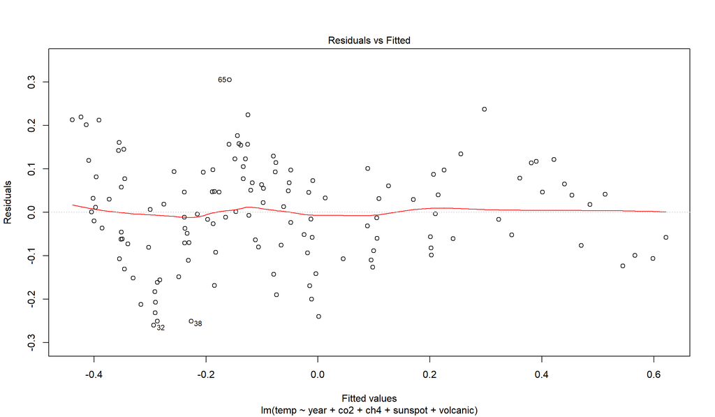

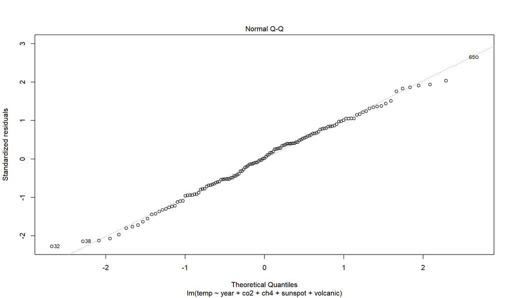

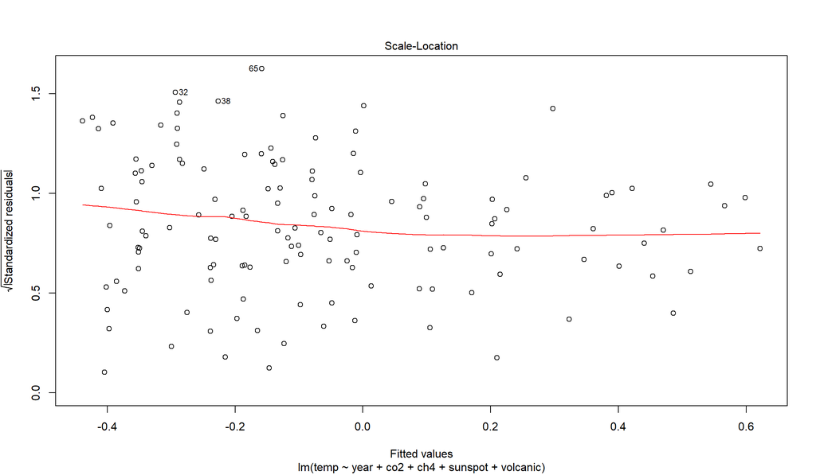

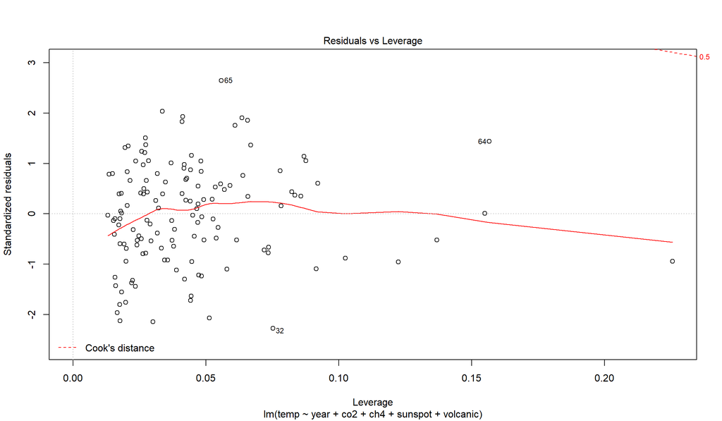

```r
plot(temp_model_1)
```

```r
par(mfrow = c(2, 2)) # set up 2 by 2 plot
plot(temp_model_1) # built-in diagnostic plots
par(mfrow = c(1, 1)) # go back to 1 by 1 plots (default)
```

[output not shown]

What do you learn from the model diagnostics? In particular, look at the “Residuals vs Fitted” plot. What does an ideal plot look like? What do you observe? Is this a problem?

From the model diagnostics, the residuals are not completely random There is a clustering of points in the begining or the left side of the graph. I guess that there is a problem with the fitted model. Ideally for the best fit model, I would expect the residuals to be completely in normal distribution. In this case, there appears to be a slight skew.

### Bootstrapping Uncertainty

Now we will consider the uncertainty in our linear model with a straightforward bootstrap. Let’s say we want to predict the temperature in 2014 if we know all the predictors in that same year (in reality, of course, this is unlikely to ever happen, but this is a homework problem!). To fit the model, of course, we can’t use the data from 2014!

To generate these bootstrapped estimates, we:

1. Use a for loop to repeat the same procedure many times
2. Re-sample the data, excluding the year we are predicting
3. Fit a linear model on the new data
4. Use the `predict` function to get the prediction of our linear model on the future data. We use the `newdata` argument to predict on new data which is the 2014 temperature.
5. Compare the uncertainty in our estimate

Here is some code for how one might do this.

```r
n_boot <- 200 # number of bootstrapped linear models
yhat <- rep(NA, n_boot) # initialize place for our estimates to go
for (n in 1:n_boot){
  new_data <- temp %>%
    filter(year < max(year)) %>%
    sample_frac(size = 1, replace = TRUE)
  lm_i <- lm(temp ~ ., data = new_data)
  yhat[n] <- predict(lm_i, newdata=filter(temp, year==max(year)))

}
```

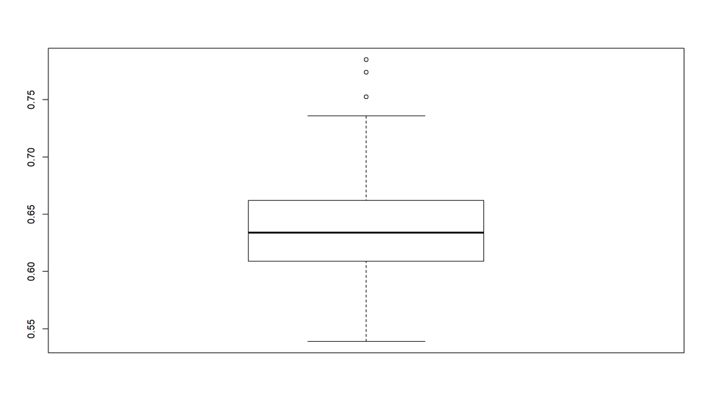

```r
boxplot(yhat[], xlab = "")
```

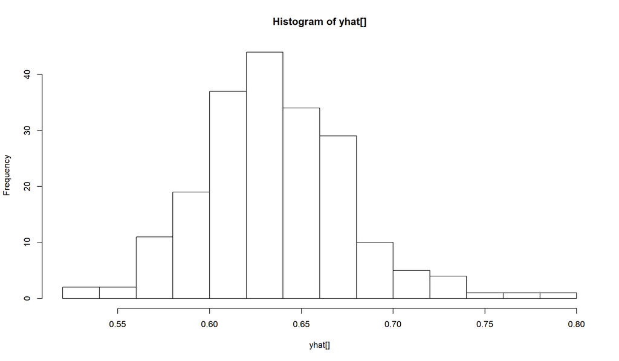

```r
hist(yhat[])
```

Using this bootstrap technique, what is the uncertainty in our estimates of 2014? Visualize this uncertainty with a plot or compute a measure of spread.

The uncertainity is visualized with the help of a boxplot graph.

Thus we can see that just by considering sampling variations – shuffling the observed data with replacement – we can capture substantial uncertainty in prediction. Do you think this is an upper or lower bound on total uncertainty?

Bootstapping is based on the assumption that the underlying distribution is empirical, and provides a lower bound on total uncertainity.

We can use this approach – bootstraping observed data and estimating some quantity of interest on the resampled data – for many things. Here we used it to compute the uncertainty in estimation on one new data point. We could also use it to estimate the uncertainty of a particular parameter, of a statistical test, of a summary statistic, of predictions on many new data points, etc. Bootstraps will be an important tool for us to address uncertainty this semester, so if you don’t understand this code please get assistance as soon as possible!

### Considering Auto-Correlation

Because our data is a time series and because the global climate is a system with some “memory”, it may have substantial autocorrelation. Let’s add $\text{temp}_{t-1}$ as a predictor into our model. We can do this with the `lag()` function in `dplyr`:

```r
temp_lag <- temp %>%
  mutate(lag_temp = lag(temp, 1)) %>%
  filter(!is.na(lag_temp))
glimpse(temp_lag)
```

```
Observations: 134
Variables: 7
$ year     <int> 1881, 1882, 1883, 1884, 1885, 1886, 1887, 1888, 1889,...
$ temp     <dbl> -0.204, -0.212, -0.290, -0.403, -0.385, -0.369, -0.42...
$ co2      <dbl> 291.2, 291.7, 292.1, 292.6, 293.0, 293.3, 293.6, 293....
$ ch4      <int> 909, 910, 911, 913, 914, 915, 916, 918, 918, 919, 920...
$ sunspot  <dbl> 54.308333, 59.608333, 63.633333, 63.508333, 51.958333...
$ volcanic <dbl> 0.0000, 0.0000, 0.0572, 0.0897, 0.0138, 0.0339, 0.032...
$ lag_temp <dbl> -0.225, -0.204, -0.212, -0.290, -0.403, -0.385, -0.36...
```

We used to have data from 1880 – why does the data now start in 1881?

Create a linear model where we add in the previous year’s temperature as a predictor. Call this `temp_model_2`.

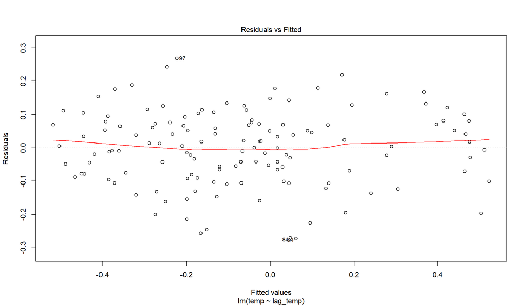

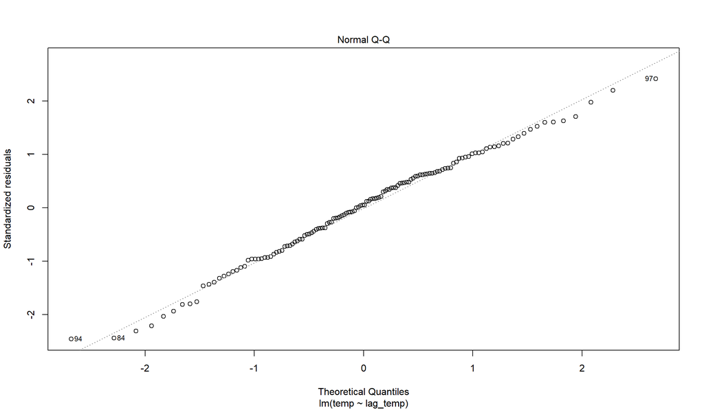

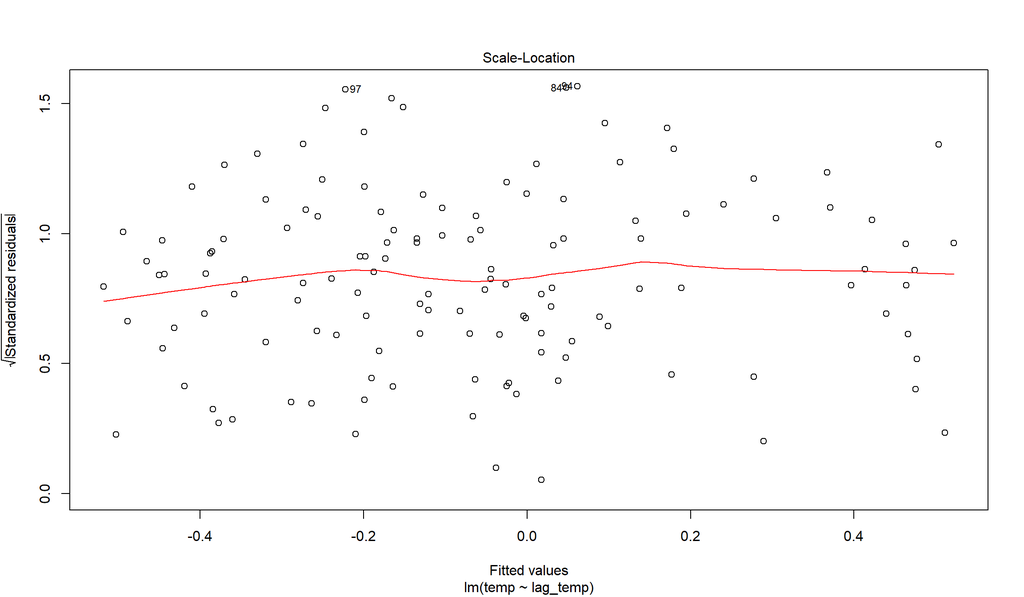

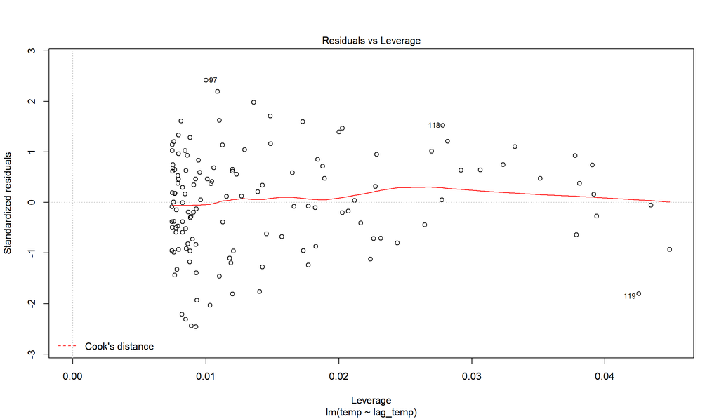

```r
temp_model_2 <- lm(temp ~ lag_temp, data = temp_lag)
plot(temp_model_2)
```

Generate the diagnostic plots as before. Does this do a better job? Why or why not? What do you suspect is going on physically?

### Polynomial Fit

Instead of using the predictors, we could fit a polynomial directly to the temperature data. This has the advantage of needing only time as a predictor!

To create a polynomial fit, we use syntax like

```r
# lm(y ~ poly(x, 3, raw=TRUE))
```

Pick a polynomial degree and create a polynomial model where temperature depends only on the year. Call this `temp_model_3`.

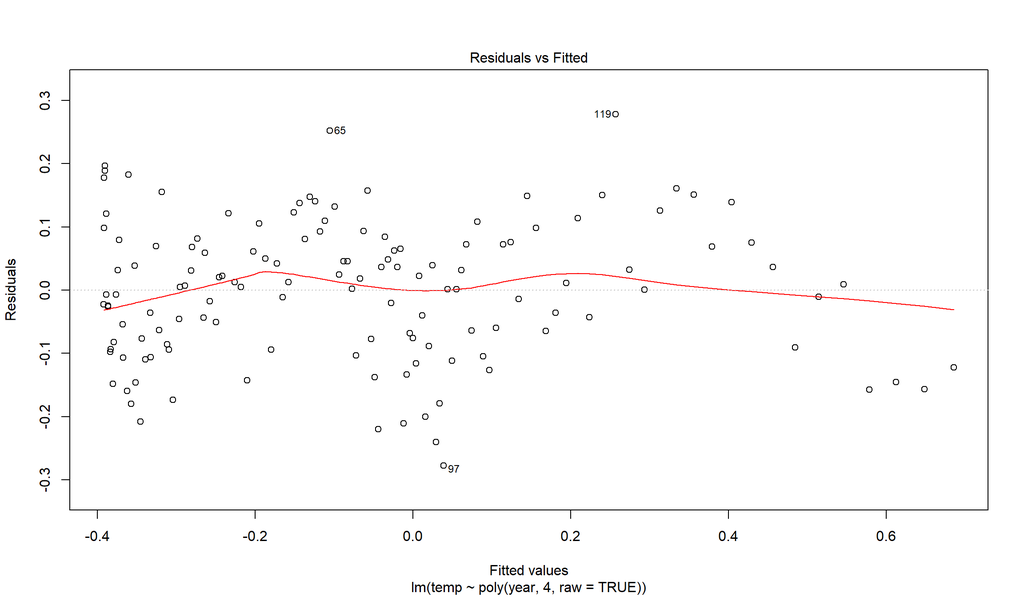

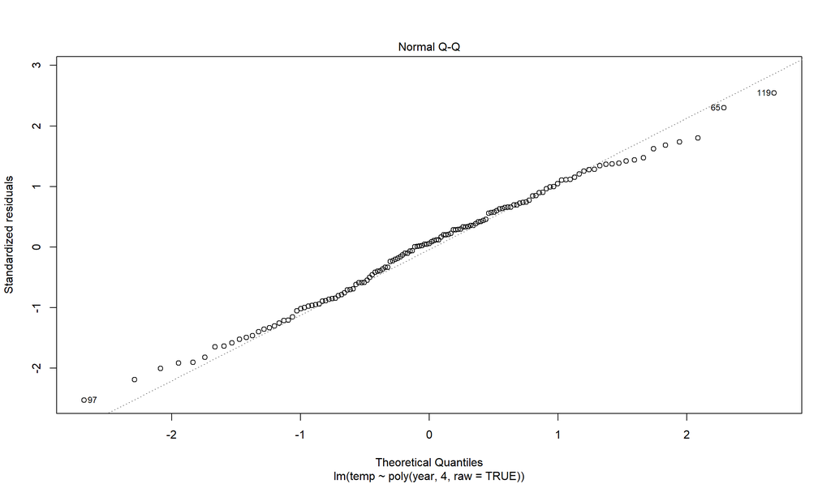

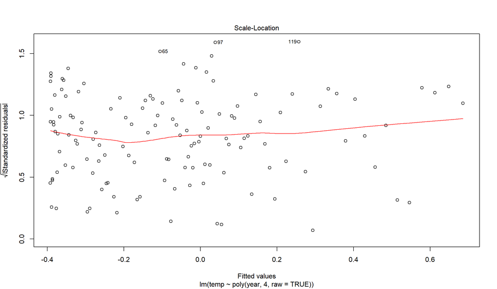

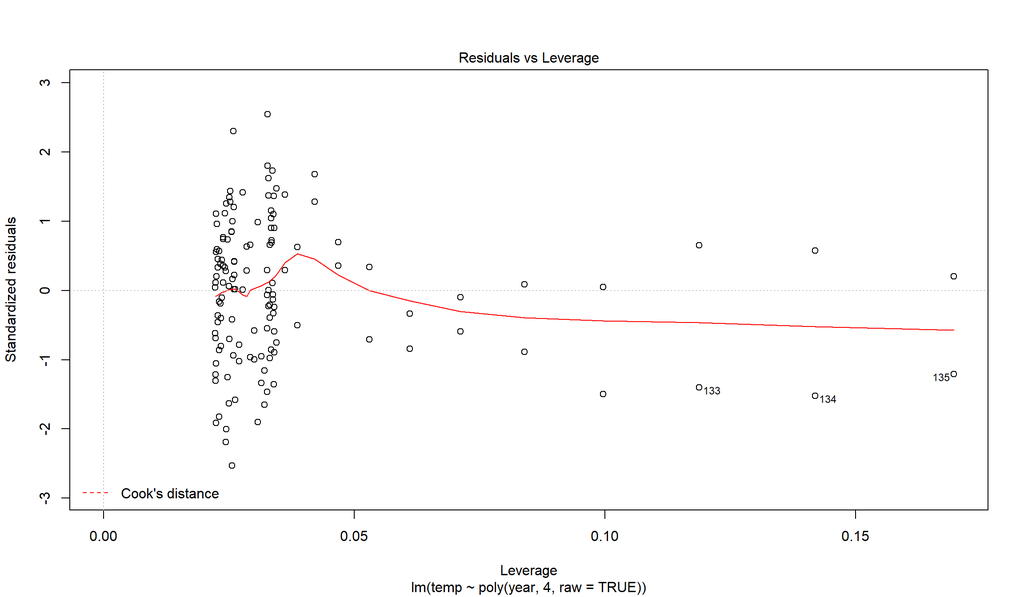

```r
temp_model_3 <- lm(temp ~ poly(year,4, raw=TRUE), data = temp)
plot(temp_model_3)
```

```r
summary(temp_model_3)
```

```
Call:
lm(formula = temp ~ poly(year, 4, raw = TRUE), data = temp)

Residuals:
      Min        1Q    Median        3Q       Max
-0.277138 -0.084011  0.006728  0.075579  0.278163

Coefficients:
                             Estimate Std. Error t value Pr(>|t|)
(Intercept)                 4.583e+05  8.685e+04   5.277 5.35e-07 ***
poly(year, 4, raw = TRUE)1 -9.430e+02  1.785e+02  -5.283 5.21e-07 ***
poly(year, 4, raw = TRUE)2  7.276e-01  1.376e-01   5.289 5.06e-07 ***
poly(year, 4, raw = TRUE)3 -2.495e-04  4.711e-05  -5.296 4.91e-07 ***
poly(year, 4, raw = TRUE)4  3.207e-08  6.049e-09   5.302 4.76e-07 ***
---
Signif. codes:  0 '***' 0.001 '**' 0.01 '*' 0.05 '.' 0.1 ' ' 1

Residual standard error: 0.1111 on 130 degrees of freedom
Multiple R-squared:  0.8538,    Adjusted R-squared:  0.8493
F-statistic: 189.8 on 4 and 130 DF,  p-value: < 2.2e-16
```

To see how well the model fit our data, we can use the following procedure with base `R` graphics:

```r
plot(temp$year, temp$temp, xlab="Year", ylab="Temperature", main="Polynomial Fit")
lines(temp$year, predict(temp_model_3))
```

[output not shown]

Call the plot diagnostics from before. How does this model do? What degree polynomial did you choose? Why? What are some potential problems of fitting a polynomial to data?

The polynomial model did better than all the models. The degree chosen is 4. It was better because the residuals are better symmetrically distributed from the mean 0(-0.277 to 0.2781). The value of the multiple R square is 0.8538, and so the variance explained by the model is 85.38%

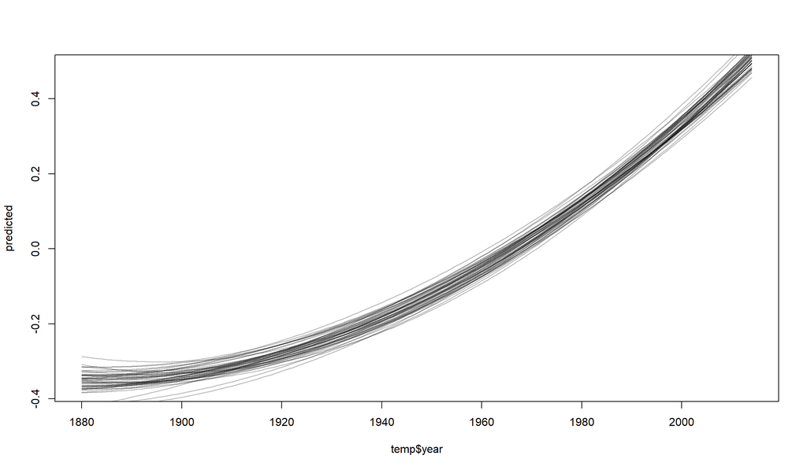

```r
n_boot <- 50
for (n in 1:n_boot){
  new_data <-
    temp %>%
    sample_frac(size = 1, replace = TRUE) %>%
    arrange(year)
  poly_i <- lm(temp ~ poly(year, 2, raw=TRUE), data = new_data)
  predicted <- predict(poly_i, newdata = temp)
  if (n == 1){
    plot(temp$year, predicted, type='l', col=alpha('black', 0.3))
  } else {
    lines(temp$year, predicted, col=alpha('black', 0.3))
  }
}
```

Modify this code for a higher-order polynomial. What happens to your uncertainty? Why?

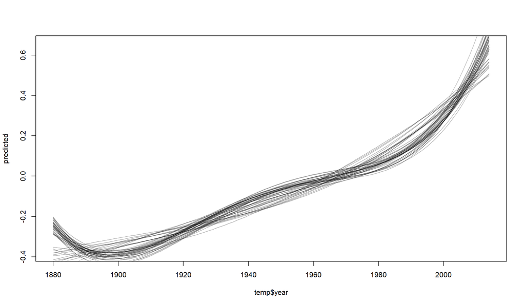

```r
n_boot <- 50
for (n in 1:n_boot){
  new_data <-
    temp %>%
    sample_frac(size = 1, replace = TRUE) %>%
    arrange(year)
  poly_i <- lm(temp ~ poly(year, 4, raw=TRUE), data = new_data)
  predicted <- predict(poly_i, newdata = temp)
  if (n == 1){
    plot(temp$year, predicted, type='l', col=alpha('black', 0.3))
  } else {
    lines(temp$year, predicted, col=alpha('black', 0.3))
  }
}
```

### Another Model

If you would like to create another model, do so here. You are not required to create another model, but if you do call it `temp_model_4`. Describe your conceptual framework, implement your model, and provide some diagnostic plots. Bootstrap the uncertainty.

### Prediction

In this section you do not need to perform any computation.

Let’s say that our true aim was to estimate the global mean temperature in 2050. This is easy for models which depend only on time (i.e. the polynomial fit) but more difficult for models which have more coefficients which we must also predict in the future. Describe how you would estimate the global mean temperature in 2050 using each of the models above. What are the advantages of each approach? What are some problems you anticipate with each approach?

Using the lm1 model: It is a simple model, with only one predictor Pros: Just need to input the year Cons: The variance captured by the model is not sufficient.

Using temp_model_1: Model with multiple predictors: Multiple regression model Pros: More accurate, because the variance captured by the model is higher. Cons: Requires the input of many parameters to predict the temperature for the year 2050. There are 6 coefficients in this model. We need to estimate all the 6 coeffiencts in the year 2050. This could be really challenging, and since we are estimating the variables, there is a possibility that they could be inaccurate.

## Survey

Did you work with anyone on this homework (*this is allowed*)? Please list their names and UNI like this:

- An Chi Ho (ah3508)
- Miriam Nielson (mn2812)

Did you use any of the suggested references? Yes If so, how helpful was it It really helped me understand the interpretations of the graphs

About how long did you spend on this homework? About 10 hours

Which statistical concept do you think you understood the best from this homework? Bootstrap The worst? Verifying the model accuracy: Those methods still not clear yet. Which programming concept introduced in this homework was most confusing? Using the bootstrap to plot the uncertainity in the model.

## Grading Rubric

- Compiling & running your document: 10
- Exploratory analysis: 10
- Temperature differences: 10
- Linear / monotonic trend: 13
- Trend by period: 10
- Multiple linear regression: 12
- Bootstrap: 5
- Autocorrelation: 8
- Polynomial fit: 10
- Optional model: up to +5
- Prediction: 10

Your interpretation of results is a very important component of your grade on each question. Approximately half of the points for each question will be awarded for correct coding / calculation / visualization. The other half will be for your interpretation of these results. If you made a mistake with your calculation but correctly interpret the results you have, you will get full points. Many of the discussion questions are open-ended, so there is not a single “right” answer; try to explain your thinking in the context of the concepts we have discussed in class.